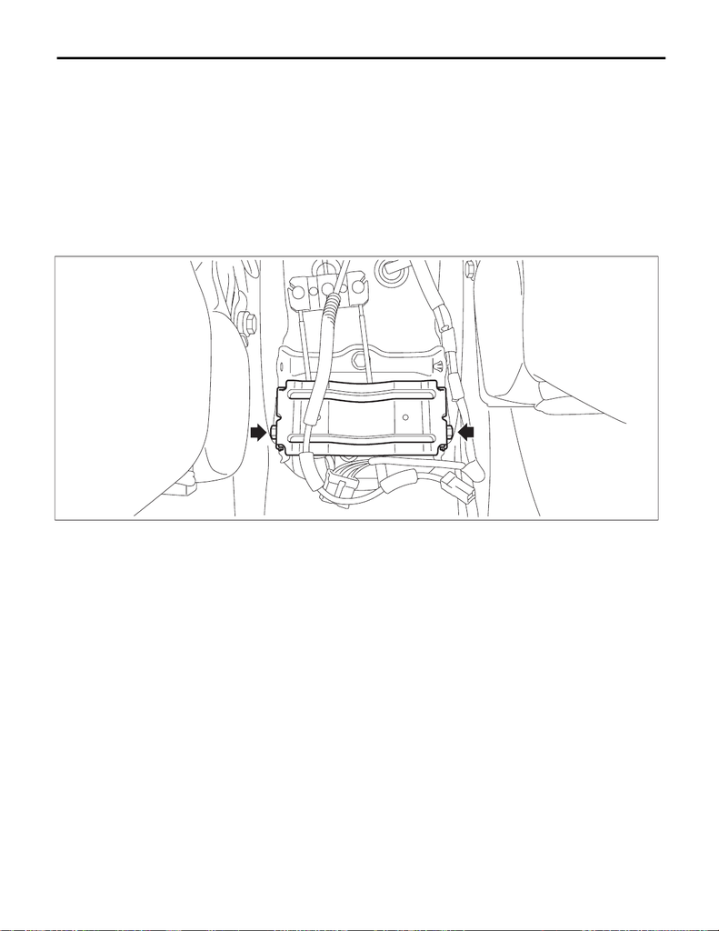

PB-4

Parking Brake Lever

PARKING BRAKE

2. Parking Brake Lever

A: REMOVAL

1) Set the wheel stoppers to tires.

2) Disconnect the ground cable from battery. <Ref. to NT-5, BATTERY, NOTE, Note.>

NOTE:

• For models other than STI model, disconnect the ground terminal from battery sensor.

• On CVT models, shift the select lever into “D” before disconnecting the battery ground cable.

• For the power seat, move the seat to the front-most position before removing the battery ground terminal.

3) Remove the driver’s seat. <Ref. to SE-9, REMOVAL, Front Seat.>

4) Remove the console box assembly. <Ref. to EI-67, REMOVAL, Console Box.>

5) Remove the bracket - console box.

PB-00346

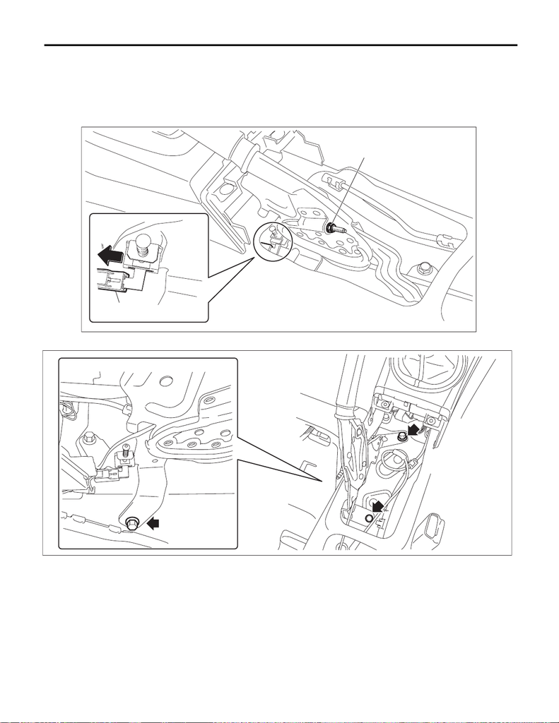

PB-5

Parking Brake Lever

PARKING BRAKE

6) Remove the lever assembly - hand brake.

(1) Disconnect the connector (a) of the switch assembly - hand brake.

(2) Remove the adjusting nut (b).

CAUTION:

nut with a new one when disassembling.

(3) Remove the bolt, and then remove the lever assembly - hand brake.

(b)

PB-00242

(a)

PB-00347

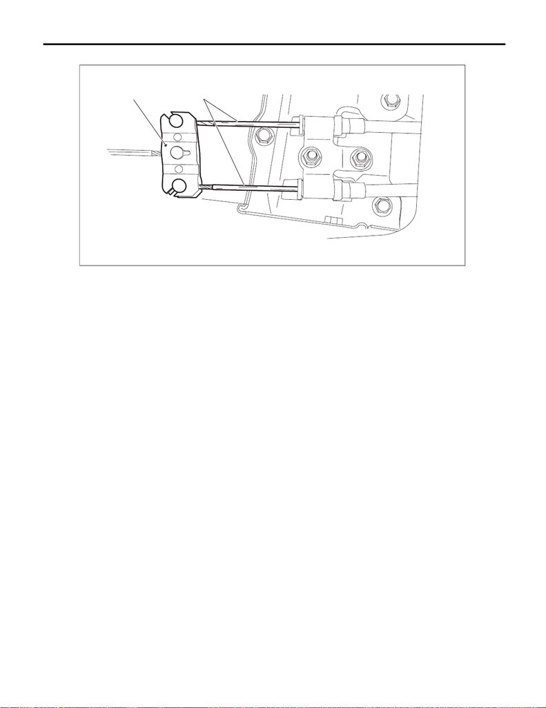

PB-6

Parking Brake Lever

PARKING BRAKE

7) Remove the inner cable end (a) from the equalizer (b).

B: INSTALLATION

1) Install the inner cable end to equalizer.

2) Install the bracket - console box.

Tightening torque:

6.5 N·m (0.7 kgf-m, 4.8 ft-lb)

3) Install the lever assembly - hand brake.

Tightening torque:

18 N·m (1.8 kgf-m, 13.3 ft-lb)

CAUTION:

Do not reuse the adjusting nut (self locking nut). Always replace with a new part.

4) Be sure to adjust the lever stroke. <Ref. to PB-7, ADJUSTMENT, Parking Brake Lever.>

5) Install the console box assembly.

6) Install the driver’s seat. <Ref. to SE-10, INSTALLATION, Front Seat.>

7) Connect the battery ground terminal. <Ref. to NT-5, BATTERY, NOTE, Note.>

NOTE:

For models other than STI model, connect the ground terminal to battery sensor.

PB-00265

(b)

(a)

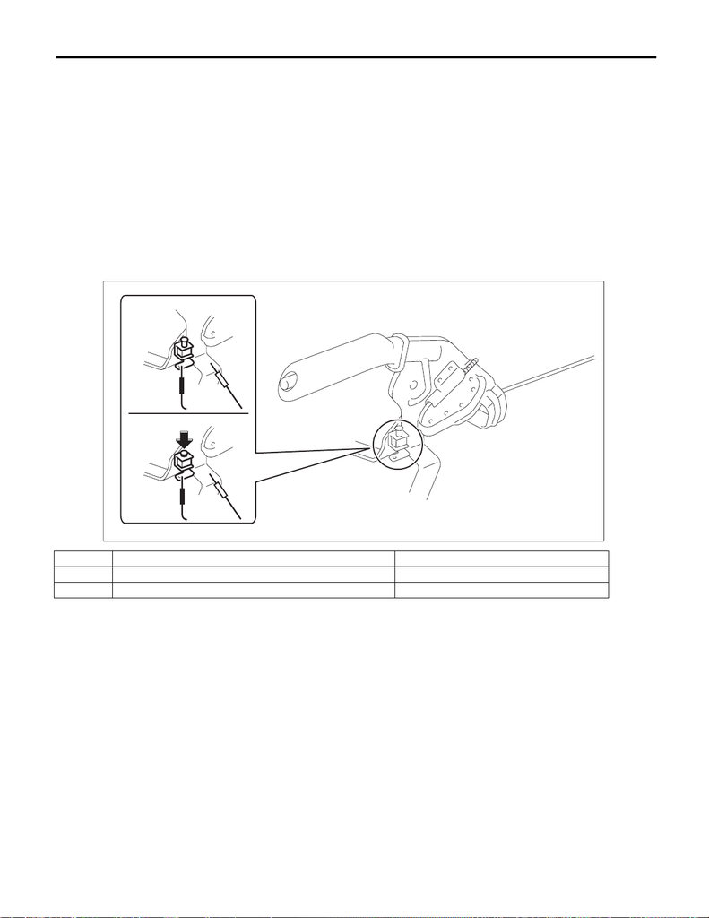

PB-7

Parking Brake Lever

PARKING BRAKE

C: INSPECTION

1. LEVER ASSY

1) Operate the lever assembly - hand brake 3 to 4 times and fully return the lever assembly - hand brake.

2) While slowly pulling up the lever assembly - hand brake, count the notches.

Lever stroke:

7 to 8 notches when pulled with a force of 200 N (20.4 kgf, 45 lbf)

Assembly (Rear Disc Brake).>

2. SWITCH ASSEMBLY

1) Measure the resistance between the switch assembly - hand brake and chassis ground.

Preparation tool:

Circuit tester

If the result of inspection is not within the specified value, replace the switch assembly - hand brake.

D: ADJUSTMENT

(Rear Disc Brake).>

Switch position Standard

A When shaft is free (ON) Less than 1 Ω

B When shaft is pressed in (OFF) 10 kΩ or more

PB-00257

A

B